# BMIN 503 Final Project

Junchao Shen

11/23/2021

## R Markdown

BMIN 503

Background: Parkinson’s Disease (PD) is the second most common neurodegenerative disease affecting over 2 million people in the United States. Patients with Parkinson’s Disease demonstrated a series of cognitive, motor and psychotic symptoms. However, up to date, there still weren’t any cliniaclly validated blood based diagnostic test that can quickly help clinicians to confirm the diagnosis of PD. The fact that different Parkinson’s patients displayed highly heterogenous sypmtoms raised further challenges to the development of such tests. Therefore, the goal of this project is to identify any potential biomarkers associated with the diagnosis and prognosis of PD, and based on that trained a classifier that can 1) differente PD patients from non-PD patients 2) different PD patients with a faster progression rate from slowly progressing PD patients with high performance.

Goal: This project aims to conduct a large-scale proteomic analysis to screen potential plasma proteins that can A) differentiate Parkinson’s patients from normal healthy controls B) differentiate fast cognitive progressors from slow cognitive progressors based on change in MoCA (Montreal Cognitive Assessment) score change over time C) differentiate fast motor progressors from slow motor progressors based on change in UPDRS-III (Unified Parkinson’s Disease Rating Scale) score over time

Analysis Plan:

A. Cross Section Analysis

Data Cleaning and Outlier Detection Since those samples were collected from two different cohorts, it would be helpful to start with a principle component analysis (PCA) to detect any potential batch effect. Besides, PCA analysis can help us quickly identify if there’s any significant outliers so that we can remove outliers before formal analysis

Differential Expression Analysis Compare the proteins expression level between normal control and subjects diagnosed with Parkinson’s Disease. Benjamini-Hochberg method was used to adjust for multiple comparison. Proteins that pass the adjusted p-value of 0.05 were considered as proteins that were significantly associated with the phenotype of Parkinson’s Disease. Fold change was calculated using log2(Control-PD). Vocalno plot was used to visualize the difference in protein expression between PD and control group.

3). Gene Set Enrichment Analysis (GSEA)

After identifying plasma proteins that differentiate PD from control, we created a dictionary to map protein names into their corresponding gene symbols. Using KEGG pathway files, GESA analysis was conducted to identify any potential underlying mechanisms associated with the proteins identified in the 2) and their associated genes.

4). Classifcation Analysis

2. Longitudinal Analysis (Cognitive Function)

Linear-mixed effects model was used to evaluate the effect of the top protein biomarkers identified in (A) on change in MoCA score over time, after age and sex were adjusted for.

Model: MoCA ~ time x top proteins + age + sex

3. Longitudinal Analysis (Motor Function)

Linear-mixed efefcts model was used to evaluate the effect of the top protein biomarekrs indentified in (A) on change in UPDRS-III score over time, after age and sex were adjusted for

Model: UPDRS ~ time x top proteins + age + sex

1. Data Cleaning and Data Preprocessing

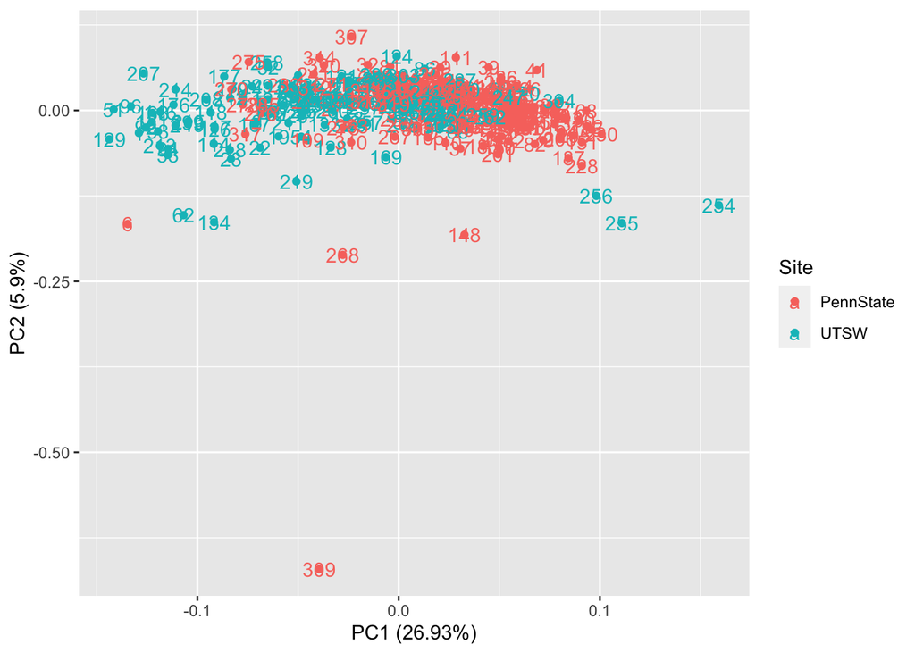

```r
# Read the proteomic dataset
df = read.csv('Protein.Demographic.csv',skip = 6)

df= df[-321,]

# Let's extract the columns that include proteine expression only
protein = df[9:1313]

# Let's first normaliz the dataset using log10 transformation
protein.log = log10(protein)

# Let's first do some quality control analysis to identify potential outliers

protein.log = protein.log[-321,]

dat.pca <- prcomp(protein.log,cor=F)
protein.log$Site = df$Site

library(ggfortify)
options(repr.plot.width=7, repr.plot.height= 5)
library(ggplot2)
autoplot(dat.pca, data = protein.log,colour = 'Site',label = TRUE)
```

```r
protein.log = protein.log[-309,]
df = df[-309,]

protein.log$GUID = df$GUID
protein.log$Group = df$Group
protein.log$Site = df$Site
protein.log$Age = df$Age
protein.log$LDOPA = df$LDOPADoseTm
protein.log$UPDRS = df$UPDRS
```

Protein Differential Expression Analysis

```r
if (!requireNamespace("BiocManager", quietly = TRUE))
  install.packages("BiocManager")
BiocManager::install("GEOquery")
for (pkg in c("GEOquery", "oligo", "limma", "hgu133plus2.db", "pd.hg.u133.plus.2", "viridis", "fgsea")) {
  if (!requireNamespace(pkg, quietly = TRUE)) {
    BiocManager::install(pkg)
  }
}
```

```
## Setting options('download.file.method.GEOquery'='auto')
```

```
## Setting options('GEOquery.inmemory.gpl'=FALSE)
```

```
## No methods found in package 'RSQLite' for request: 'dbListFields' when loading 'oligo'
```

```r
library(GEOquery)
library(oligo)
library(limma)
library(viridis)
library(GEOquery)

design <- model.matrix(~ -1 + factor(protein.log$Group))

colnames(design) <- levels(factor(protein.log$Group))

fit <- lmFit(t(protein.log[,1:1305]), design)

fit.contrast <- makeContrasts(diff = Control - PD,
                              levels = design)

fit2 <- contrasts.fit(fit, fit.contrast)

fit2 <- eBayes(fit2)

exposure_results <- topTable(fit2, coef = "diff", adjust = "BH", num = Inf)

head(exposure_results)
```

```
##                       logFC  AveExpr         t      P.Value    adj.P.Val
## BSP             -0.10464754 3.593359 -5.094329 5.983934e-07 0.0007809034
## ApoM            -0.09686079 4.075863 -4.924168 1.358347e-06 0.0007874847
## OMD             -0.08956491 3.844542 -4.863440 1.810310e-06 0.0007874847
## IDS             -0.08462367 3.545450 -4.611235 5.789065e-06 0.0018886824
## NCAM.120        -0.05122450 4.073848 -4.450289 1.184483e-05 0.0030915011
## Stanniocalcin.1 -0.06148008 3.318286 -4.335366 1.950327e-05 0.0042419619
##                        B
## BSP             5.729636
## ApoM            4.955615
## OMD             4.684825
## IDS             3.591334
## NCAM.120        2.920094
## Stanniocalcin.1 2.453662
```

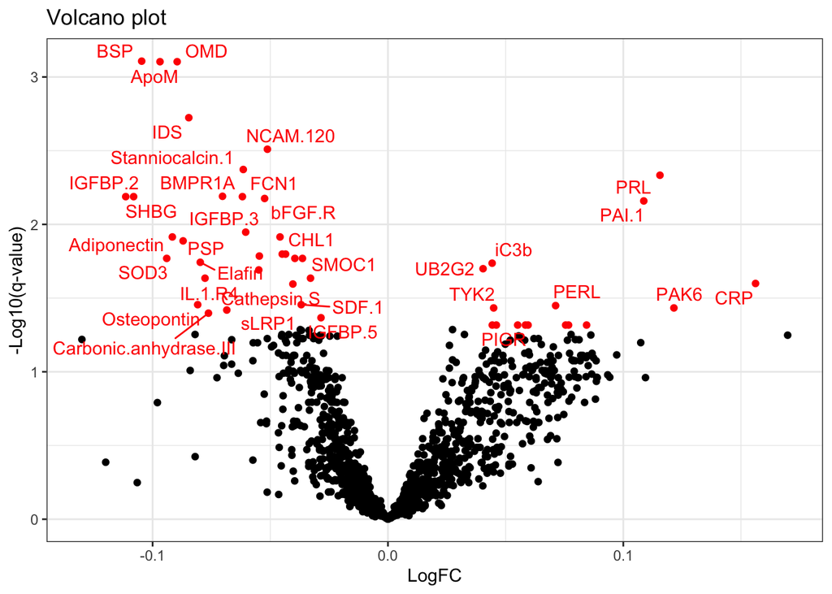

```r
library(ggplot2)
library(ggrepel)
# Assign (in)significant genes
exposure_results$sig <- rep("insignificant", nrow(exposure_results))
exposure_results$sig[which(exposure_results$adj.P.Val<0.05)] <- "significant"
v1 = ggplot(exposure_results, aes(x = logFC, y = -log10(adj.P.Val), color = sig)) +
  geom_point() +
  theme_bw() +
  ggtitle("Volcano plot") +
  xlab("LogFC")+
  ylab("-Log10(q-value)") +
  scale_color_manual(values = c("black", "red")) +
  theme(legend.position = "none")

v1+geom_text_repel(data=head(exposure_results, 40), aes(label=rownames(exposure_results)[1:40]))
```

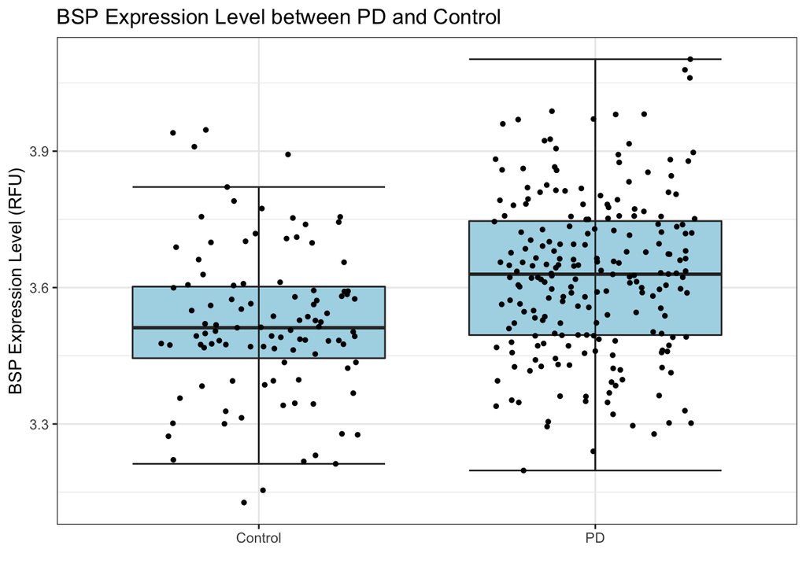

```r
dict = read.csv('Protein.Demographic.csv',skip = 1)

dict1 = t(dict[4:5,])[-1:-8,]
rownames(dict1) = NULL
colnames(dict1) = c('SYMBOL','Protein.Name')
exposure_results$Protein.Name = rownames(exposure_results)
protein_gene = merge(exposure_results,dict1,by = 'Protein.Name')

DE_res = protein_gene

write.table(exposure_results, "./Protein_DE_results.txt", row.names = F,
            col.names = T, quote = F, sep = "\t")

df_boxplot1 = data.frame(
  expression = protein.log[,'BSP'],
  status = protein.log$Group)

ggplot(df_boxplot1, aes(x = status, y = expression)) +
  geom_boxplot(outlier.colour = NA, color = "grey18", fill = "lightblue") +
  stat_boxplot(geom = "errorbar", color = "grey18") +
  geom_jitter(size = 1, position = position_jitter(width = 0.3)) +
  ggtitle("BSP Expression Level between PD and Control") +
  xlab(" ") +
  ylab("BSP Expression Level (RFU)") +
  theme_bw() +
  theme(legend.position = "none")
```

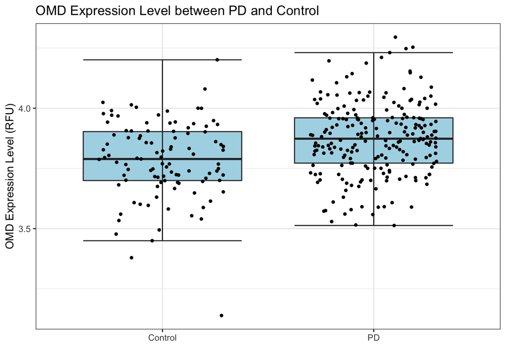

```r
df_boxplot2 = data.frame(
  expression = protein.log[,'OMD'],
  status = protein.log$Group)

ggplot(df_boxplot2, aes(x = status, y = expression)) +
  geom_boxplot(outlier.colour = NA, color = "grey18", fill = "lightblue") +
  stat_boxplot(geom = "errorbar", color = "grey18") +
  geom_jitter(size = 1, position = position_jitter(width = 0.3)) +
  ggtitle("OMD Expression Level between PD and Control") +
  xlab(" ") +
  ylab("OMD Expression Level (RFU)") +
  theme_bw() +
  theme(legend.position = "none")
```

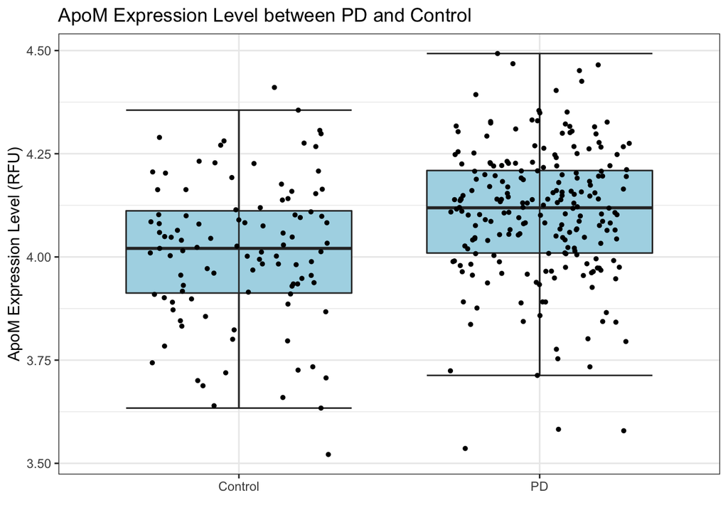

```r
df_boxplot3 = data.frame(
  expression = protein.log[,'ApoM'],
  status = protein.log$Group)

ggplot(df_boxplot3, aes(x = status, y = expression)) +
  geom_boxplot(outlier.colour = NA, color = "grey18", fill = "lightblue") +
  stat_boxplot(geom = "errorbar", color = "grey18") +
  geom_jitter(size = 1, position = position_jitter(width = 0.3)) +
  ggtitle("ApoM Expression Level between PD and Control") +
  xlab(" ") +
  ylab("ApoM Expression Level (RFU)") +
  theme_bw() +
  theme(legend.position = "none")
```

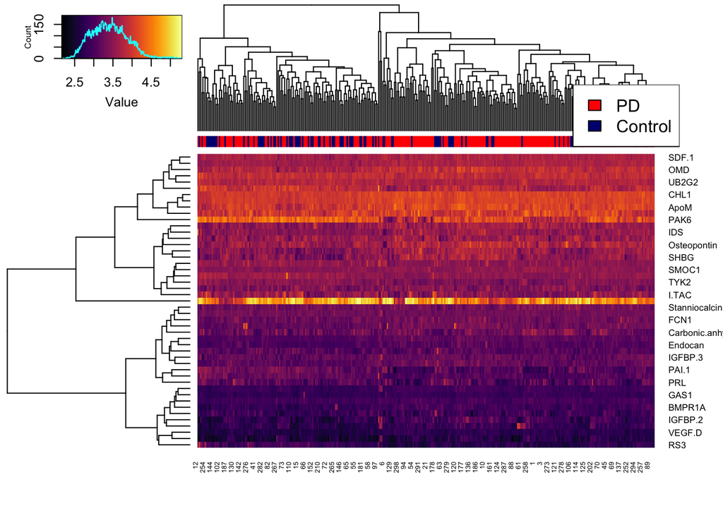

```r
options(repr.plot.width=14, repr.plot.height= 15)
library(gplots)
# keep top 200 genes
top_results <- subset(exposure_results,sig =='significant')
top.eset <- protein.log[colnames(protein.log) %in% row.names(top_results)]
status.colors <- unlist(lapply(protein.log$Group,
                               function (x) {if (x == "PD") "red"
                                 else "navy"}))
heatmap.2(t(top.eset), col = viridis(256, option = "B"),
          trace = "none", keysize = 1.5, key.title = NA,
          ColSideColors = status.colors)
legend("topright", legend = c("PD","Control"), fill = c("red", "navy"))
```

```r
library(fgsea)
kegg <- gmtPathways("./c2.cp.kegg.v7.4.symbols.gmt")
reactome <- gmtPathways("./c2.cp.reactome.v7.4.symbols.gmt")
pathways <- c(kegg, reactome)
head(DE_res)
```

```
##   Protein.Name        logFC  AveExpr          t      P.Value  adj.P.Val
## 1         ABL1  0.016198841 2.148463  0.9153406 0.3607002121 0.59373515
## 2         ABL2 -0.007336859 3.245519 -0.7138443 0.4758423919 0.68920568
## 3         ACE2  0.007742940 2.755534  0.4798996 0.6316257721 0.79677100
## 4         ACTH  0.006590667 2.650429  0.3888161 0.6976700768 0.83479717
## 5       ADAM12  0.002574039 2.663372  0.1578207 0.8746973233 0.93334438
## 6  Adiponectin -0.091616177 3.555267 -3.8473203 0.0001440704 0.01216739
##           B           sig SYMBOL
## 1 -6.087681 insignificant   ABL1
## 2 -6.248323 insignificant   ABL2
## 3 -6.385116 insignificant   ACE2
## 4 -6.423896 insignificant   POMC
## 5 -6.485802 insignificant ADAM12
## 6  0.594801   significant ADIPOQ
```

```r
library(dplyr)
DE_res <- DE_res %>%
  filter(!is.na(SYMBOL)) %>%
  group_by(SYMBOL) %>%
  arrange(P.Value) %>%
  filter(row_number() == 1) %>%
  data.frame()


gene_list <- DE_res$t
names(gene_list) <- DE_res$SYMBOL
gene_list <- sort(gene_list, decreasing = T)
head(gene_list, 5)
```

```
##      PRL       C3   UBE2G2      CRP      LPO
## 4.278304 3.613029 3.579063 3.476249 3.343124
```